# My Le Mans Ultimate Performance

## An Overview of My Last 20 Races

This graph shows my performance from the last 20 races. Ideally the blue line is on or below the red line as that means I have kept my position or gained positions in the race.

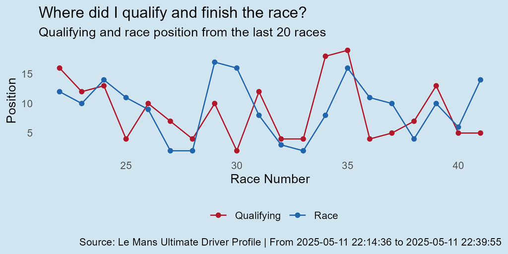

## My Positions Gained From The Last 20 Races

This graph shows my positions gained in the last 20 races. Some races I lost quite a bit of positions (such as race 30 where I lost 14 positions). This was most likely due to crashes/collisions with other cars which meant I had to repair my car and therefore lost positions.

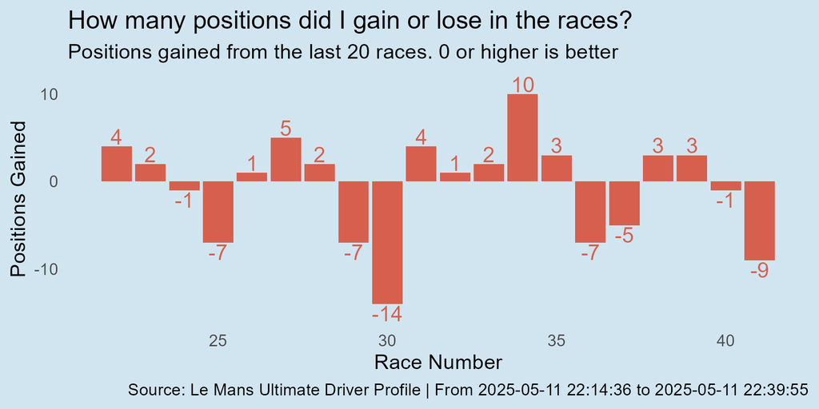

## My Overall Performance

The next section will go through my overall statistics from a total of 41 races.

## My Overall Qualifying Position

This graph shows my overall qualifying position from 41 races. The most frequent position I’ve qualified in is 4th (with 6 counts).

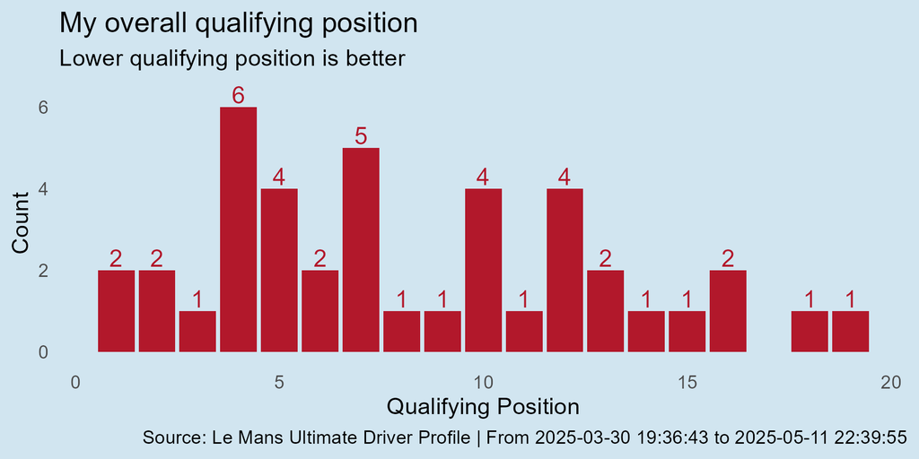

## My Overall Race Position

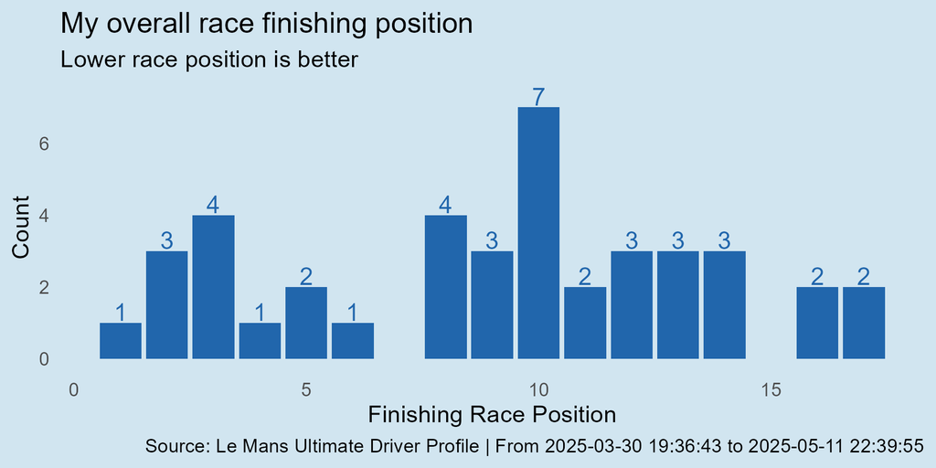

## My Total Races At Each Track

The most races I’ve had is at Fuji Speedway with 14 races.

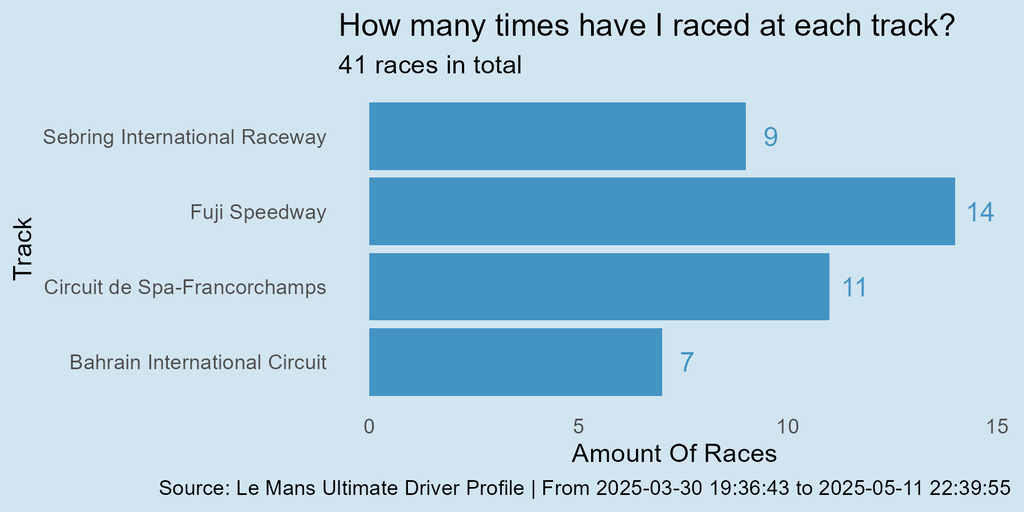

## My Total Races In Each Car Class

LMGT3 is the most I’ve raced in since most of the races are only with the LMGT3 class.

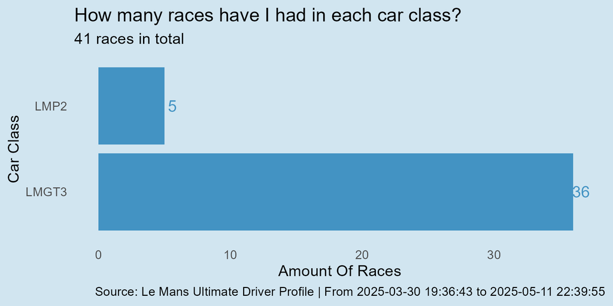

## My Total Races In Each Car

Most of my races are in the McLaren for the LMGT3 class as I find it the easiest to drive. There is only one car for the LMP2 class which is the Oreca 07 so that’s why it’s the only LMP2 car on the list.

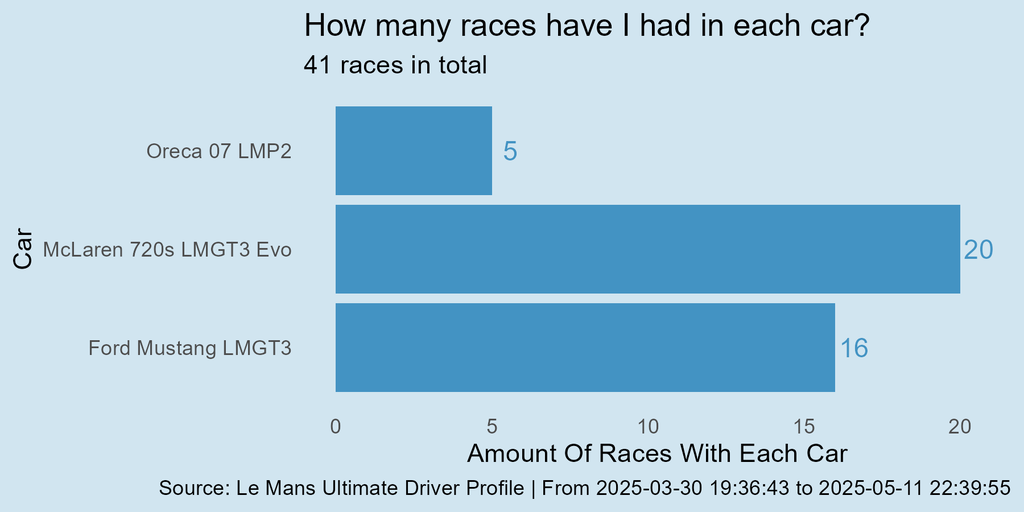